# Informe Analisis Estadistico

Alberto Coll Fernández

2023-03-29

# Introducción y estructura de los datos

Todo el análisis estadístico lo he realizado utilizando R 4.2.2 y RStudio 2022.12.0, y empleando únicamente los datos procedentes de las anémonas que permanecieron en cultivo, dejando los salvajes para otro análisis. El conjunto de datos resultante contaba 36 observaciones de 25 variables. La cabeza del conjunto de datos seria la siguiente:

```
## # A tibble: 6 × 25
##   individuo playa     cultivo corte  tiempo SOD_t CAT_t  GPx_t  GR_t GST_t DTD_t
##       <int> <fct>     <fct>   <fct>  <chr>  <dbl> <dbl>  <dbl> <dbl> <dbl> <dbl>
## 1        16 Calahonda Si      disse… 0       65.7  NA    5.81   15.0  129.  3.74
## 2        17 Calahonda Si      disse… 0       65.2  28.4 31.8    12.4  158.  5.77
## 3        18 Calahonda Si      disse… 0       88.8  40.7 13.2    21.3  170.  5.60
## 4        19 Almuñecar Si      disse… 0       64.3  28.0  4.47   14.1  160.  3.87
## 5        20 Almuñecar Si      disse… 0       72.9  34.9 14.5    17.3  138.  6.04
## 6        21 Almuñecar Si      disse… 0       69.8  31.3  0.325  13.2  166.  4.41
## # … with 14 more variables: G6PDH_t <dbl>, TEAC_t <dbl>, MDA_t <dbl>,
## #   proteina_t <dbl>, SOD_p <dbl>, CAT_p <dbl>, GPx_p <dbl>, GR_p <dbl>,
## #   GST_p <dbl>, DTD_p <dbl>, G6PDH_p <dbl>, TEAC_p <dbl>, MDA_p <dbl>,
## #   proteina_p <dbl>
```

De estas, las variables relevantes para el ensayo son **playa**, **corte** y **tiempo**. La variable **playa** hace referencia al punto de muestreo de los animales del ensayo, y toma tres valores: Calahonda, Salobreña y Almuñécar.

La variable **corte** hace referencia al tratamiento principal del experimento: las anémonas en el grupo experimental *dissected* fueron seccionadas para estimular su reproducción asexual, mientras que se estableció un grupo *control* que no sufrió tal tratamiento.

Por último, la variable **tiempo** responde a los dos muestreos que se realizaron durante el experimento: uno de ellos a las pocas semanas de la sección de las anémonas (*primer muestreo*), y el segundo a los cuatro meses, cuando las anémonas habían madurado sexualmente (*segundo muestreo*). No recuerdo ahora mismo en qué mes se realizó cada uno, pero tenía intención de utilizar el nombre del mes para las gráficas y resultados.

El objetivo principal del ensayo es comprobar cómo responden las anémonas a la reproducción asexual en condiciones de cultivo, y cómo interacciona este evento con su maduración sexual en cautividad.

Para ello, se midieron distintas enzimas involucradas en sistemas antioxidantes del animal (**SOD**, **CAT**, **GPx**, **GR**, **GST**, **DTD** y **G6PDH**), además de su capacidad antioxidante total (**TEAC**), su concentración de **proteína**, y su concentración de malondialdehído (**MDA**). Estas variables se midieron por duplicado, tanto en los tentáculos del animal como en su tronco o pie, por lo que en total hacen 20 variables de interés.

# Metodología y elección del modelo

Que quiere decir que cada una de las variables se modeló como una función de corte, tiempo, playa, y la interacción entre estos factores. El término playa aparece porque el análisis exploratorio desveló que en ocasiones los individuos procedentes de distinta playa seguían tendencias diferentes para determinadas variables.

He optado por este modelo en lugar de hacer varios más sencillos para no realizar tantas comparaciones y test estadísticos, que al final incrementan mucho la probabilidad de error de tipo I.

Tras ajustar los modelos, para cada variable, he comprobado si existía un efecto significativo de la interacción corte-tiempo, y, en caso de no haberla, opté por un modelo más parsimonioso, sin ese término de interacción.

Una vez ajustados los modelos, he comprobado el ajuste y las asunciones generales de modelos lineales. La asunción de normalidad de los residuos la he comprobado por medio del test de Shapiro-Wilk, y sólo una variable (GR tentacular) violó está asunción. Para resolverlo, apliqué una transformación logarítmica. La asunción de homocedasticidad la comprobé visualmente mediante la examinación de la gráfica de Escala-Localización de cada modelo, y no encontré grandes violaciones de esta asunción (hay que tener en cuenta que con tan poco tamaño de muestra siempre hay irregularidades).

Cuando para una variable se detectaron efectos significativos de cualquier tipo, hice un test post-hoc (Test de Tukey) para examinar en detalle dichas diferencias. Por el momento he usado para las gráficas las letras fruto del ANOVA con todos los grupos, pero en algunos casos no se detectan diferencias, así que tengo intención de comparar grupo a grupo como ya hicimos.

He elaborado dos tipos de gráficas para visualizar los datos. Por un lado, gráficas de barras más tradicionales, y por otro lado, gráficas de interacción, que favorecen la visualización de los efectos de **corte** y **tiempo**.

# Resultados

## Superóxido dismutasa (SOD)

En las gráficas de barras, he separado en dos paneles diferentes los datos del primer y segundo muestreo (variable **tiempo**), mientras que en el eje x se encuentra la variable **corte**. Las playas se muestran mediante el código de color. Esta disposición se puede cambiar, así que si quieres alguna modificación en las gráficas basta con decirme qué variable quieres en cada sitio.

Los datos utilizados corresponden a la media error estándar de la media (SEM). Las letras y símbolos de las diferencias significativas aún no están correctamente puestos, pero ya he puesto una nota al pie con los símbolos que voy a utilizar. Al haber tres factores, tengo que usar algo más que letras y asteriscos, pensé en un +, pero coméntame si se suele usar otra cosa porque no lo sé.

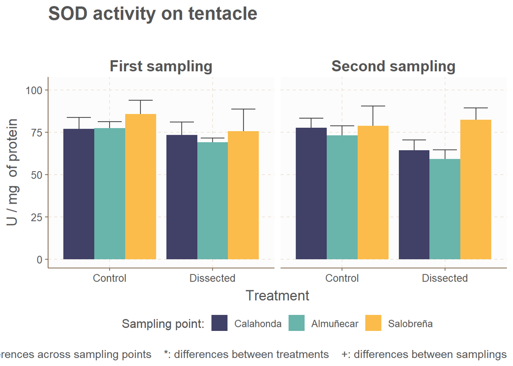

La actividad SOD tentacular se mantuvo relativamente uniforme en todos los grupos experimentales, con una ligera tendencia a mayor actividad en individuos procedentes de Salobreña, pero sin llegar a ser significativas. La gráfica de interacción sería la siguiente:

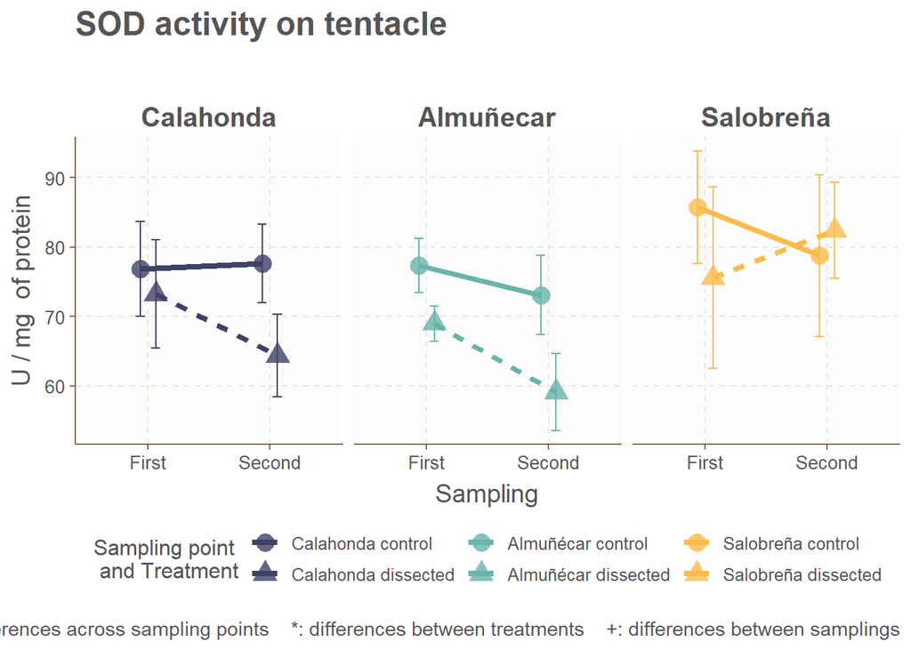

En este tipo de gráficas he separado en tres paneles los datos de cada playa, utilizando además un color distinto para cada una de ellas. Dentro de cada panel, en el eje x tenemos la variable **tiempo**, mientras que el corte lo vemos con dos formas diferentes de cada punto. De nuevo los datos son la media SEM. En esta gráfica podemos ver de nuevo esa tendencia ligeramente diferente en Salobreña.

En el caso de la SOD pedia, sí que se detectaron diferencias significativas, en concreto asociadas a la variable **tiempo** y a su interacción con **corte**. La gráfica de barras es la siguiente:

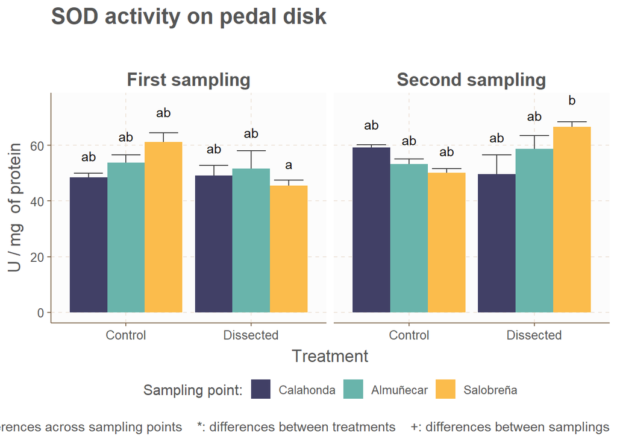

En este caso, las letras del test de Tukey prácticamente no detectan diferencias al comparar todos los grupos. Esta gráfica de barras para mi gusto es muy liosa, y pienso que se ve bastante mejor la situación en la gráfica de interacción:

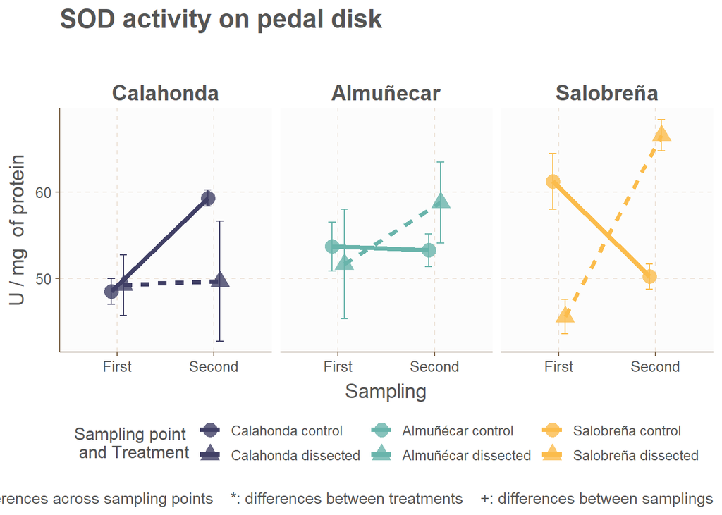

Ahora sí, se puede observar cómo la maduración parece incrementar los niveles de actividad SOD en el disco pedio, sobre todo para los individuos que además fueron cortados, de ahí la significación estadística de la interacción entre ambas variables. Hay que destacar que en Calahonda tenemos el caso contrario, lo que indica que organismos de origen diferente responden de diferente manera a los tratamientos. Aun así, hay que destacar que estas diferencias, aunque significativas, son de pequeña magnitud.

## Catalasa (CAT)

En esta enzima sí que encontramos diferencias significativas de mayor relevancia. Vamos primero con la gráfica de barras de la catalasa tentacular:

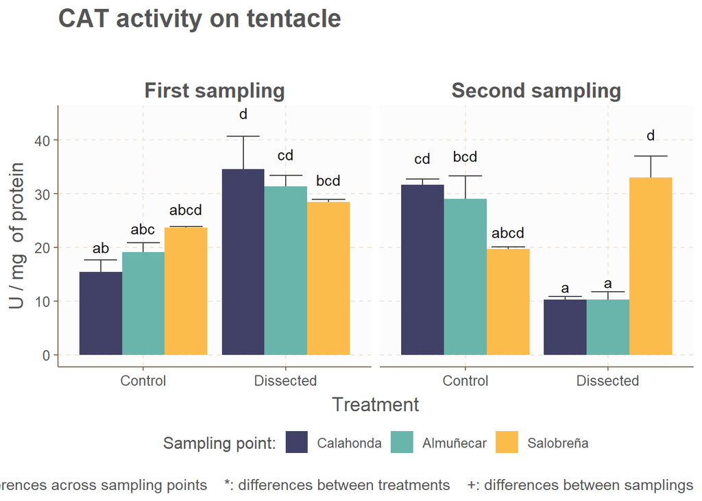

La catalasa tentacular muetra una clara tendencia diferente en los individuos de Salobreña, que se hace evidente en el grupo que fue cortado y maduró sexualmente. A parte de esto, tenemos un efecto de interacción **corte**:**tiempo**, que se aprecia muy bien en la gráfica de interacción:

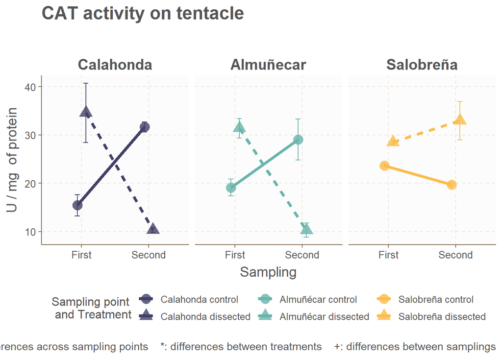

Las líneas que se cruzan en Calahonda y Almuñécar indican que, según el individuo haya sido cortados o no, la actividad catalasa responde incrementándose o disminuyendo con la maduración sexual.También se intuye una diferencia en los individuos cortados inmaduros, que fue marginalmente significativa en el modelo estadístico.

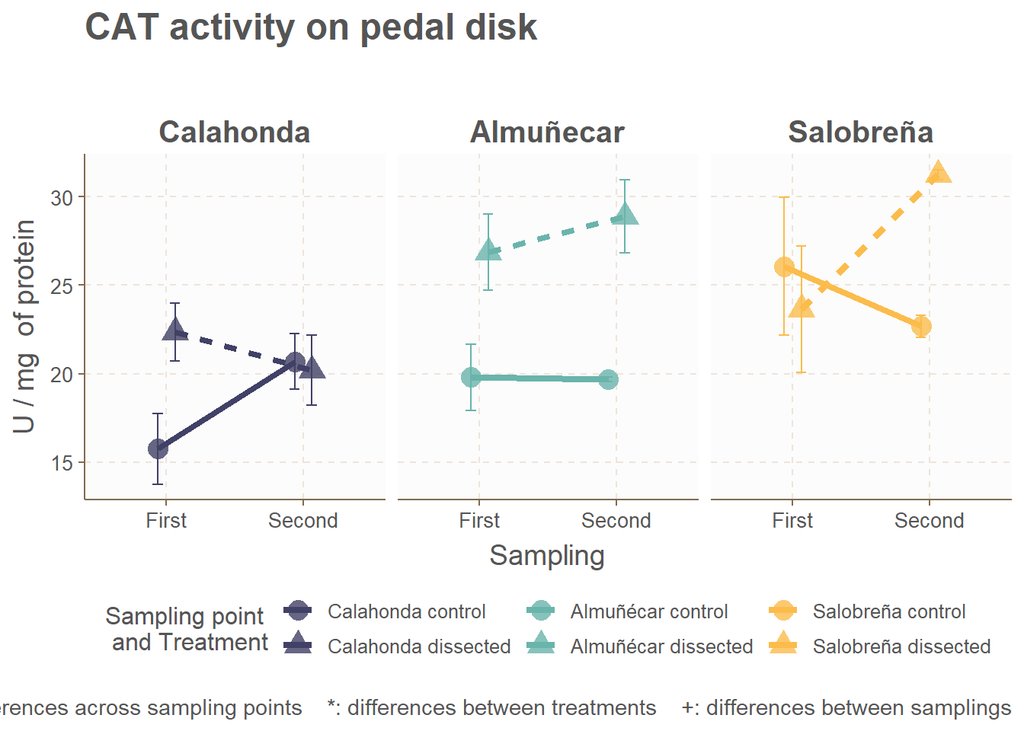

En cuanto a la CAT en disco pedio, vemos que el corte produce un efecto muy patente en su actividad, y que tambien hay diferencias entre las tres playas. En este caso no hubo ningún efecto de la maduración sexual ni ninguna interacción. A partir de ahora voy a omitir la gráfica de barras para no alargar demasiado el documento, y porque creo que es mucho más visual en la de interacción.

## Glutatión peroxidasa (GPx)